# 人工智慧 進階課程 - Deep Learning- Capsule Networks Part- 04 - An introduction to Capsule Network - Python Tutorial

# 預測 Predictions

```python
- 進行一些預測
    - 首先從測試集 Test Set 獲得一些圖片
    - 接著 開始一個 Session
    - 恢復已經訓練好的模型 - Trained Model
- 評估 Evaluate `cap2_output`
    - 獲得 膠囊網絡的輸出向量 Vectors
    - `decoder_output`來重新構造
        - 用`y_pred`
            - 來獲得類型預測 Class Predictions
```

```python
n_samples = 5

sample_images = mnist.test.images[:n_samples].reshape([-1, 28, 28, 1])

with tf.Session() as sess:
    saver.restore(sess, checkpoint_path)
    caps2_output_value, decoder_output_value, y_pred_value = sess.run(
            [caps2_output, decoder_output, y_pred],
            feed_dict={X: sample_images,
                       y: np.array([], dtype=np.int64)})
```

- 傳遞的 `y` 使用了一個空的數組
  - 不過 TensorFlow 並不會用到它
- 繪製 Plot
  - 相應的重新構造 reconstructions 和預測 predictions
  - 這些圖片和 標籤繪製

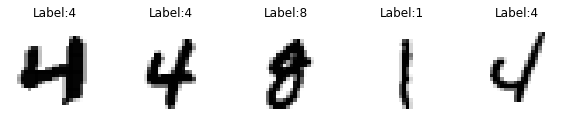

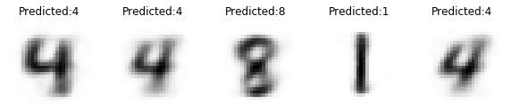

```python
sample_images = sample_images.reshape(-1, 28, 28)
reconstructions = decoder_output_value.reshape([-1, 28, 28])

plt.figure(figsize=(n_samples * 2, 3))
for index in range(n_samples):
    plt.subplot(1, n_samples, index + 1)
    plt.imshow(sample_images[index], cmap="binary")
    plt.title("Label:" + str(mnist.test.labels[index]))
    plt.axis("off")

plt.show()

plt.figure(figsize=(n_samples * 2, 3))
for index in range(n_samples):
    plt.subplot(1, n_samples, index + 1)
    plt.title("Predicted:" + str(y_pred_value[index]))
    plt.imshow(reconstructions[index], cmap="binary")
    plt.axis("off")

plt.show()
```

# 理解 输出 向量

```
- Interpreting the Output Vectors
```

```python
- 假設 調整一下輸出向量
    - 查看 對 姿態參數 Pose Parameters
- 首先 - 檢查`cap2_output_value` NumPy 數組的形狀 Shape
```

```python
caps2_output_value.shape
```

```
(5, 1, 10, 16, 1)
```

```python
- 然後 假設 創建一個 假設函數
    - 該函數
        - 在所有的 輸出向量裡
        - 對於每個 16（維度）姿態參數 Pose Parameters
            - 進行調整
    - 每個調整過的輸出向量
        - 將和原來的輸出向量相同
    - 姿態參數 中的一個
        - 會加上一個 -0.5 到 0.5之間 變動的 值
    - 默認的會有11個步數(-0.5, -0.4, ..., +0.4, +0.5)

    - 這個函數會返回一個數組
        - 其形狀為
        - (_調整過的姿態參數_=16, _步數_=11, _batch size_=5, 1, 10, 16, 1)：
```

```python
def tweak_pose_parameters(output_vectors, min=-0.5, max=0.5, n_steps=11):
    steps = np.linspace(min, max, n_steps) # -0.25, -0.15, ..., +0.25
    pose_parameters = np.arange(caps2_n_dims) # 0, 1, ..., 15
    tweaks = np.zeros([caps2_n_dims, n_steps, 1, 1, 1, caps2_n_dims, 1])
    tweaks[pose_parameters, :, 0, 0, 0, pose_parameters, 0] = steps
    output_vectors_expanded = output_vectors[np.newaxis, np.newaxis]
    return tweaks + output_vectors_expanded
```

- 計算所有的調整過的輸出向量
  - 並且重塑Reshape 結果到
  - (*parameters*×*steps*×*instances*, 1, 10, 16, 1)
- 傳遞該數組 到 解碼器 Decoder 中

```python
n_steps = 11

tweaked_vectors = tweak_pose_parameters(caps2_output_value, n_steps=n_steps)
tweaked_vectors_reshaped = tweaked_vectors.reshape(
    [-1, 1, caps2_n_caps, caps2_n_dims, 1])
```

- 現在 遞送 Feed 這些調整過的輸出向量
  - 到解碼器 並且 獲得重新構造 Reconstructions

```python
tweak_labels = np.tile(mnist.test.labels[:n_samples], caps2_n_dims * n_steps)

with tf.Session() as sess:
    saver.restore(sess, checkpoint_path)
    decoder_output_value = sess.run(
            decoder_output,
            feed_dict={caps2_output: tweaked_vectors_reshaped,
                       mask_with_labels: True,
                       y: tweak_labels})
```

- 重塑 REshaoe 解碼器 Decoder的輸出
  - 以便於我能夠在輸出維度，調整步數，和 預測實例之上進行迭代

```python
tweak_reconstructions = decoder_output_value.reshape(
        [caps2_n_dims, n_steps, n_samples, 28, 28])
```

- 最後，繪製所有的重新構造
  - 對於前三個輸出維度 3 Output Dimensions
    - 對於每個調整中的步數(列column)和每個數字(行row)

```
Tweaking output dimension #0
```

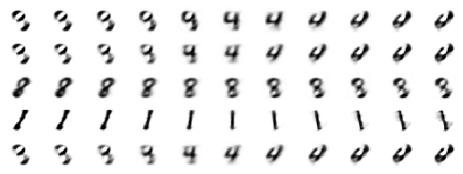

```
Tweaking output dimension #1
```

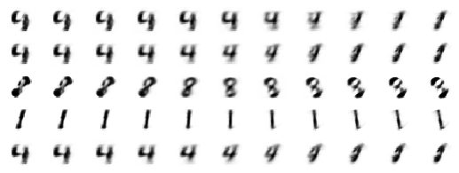

```
Tweaking output dimension #2
```

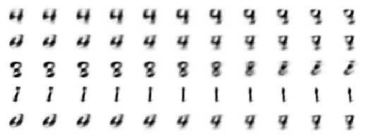

```python
for dim in range(3):
    print("Tweaking output dimension #{}".format(dim))
    plt.figure(figsize=(n_steps / 1.2, n_samples / 1.5))
    for row in range(n_samples):
        for col in range(n_steps):
            plt.subplot(n_samples, n_steps, row * n_steps + col + 1)
            plt.imshow(tweak_reconstructions[dim, col, row], cmap="binary")
            plt.axis("off")
    plt.show()
```

# 參考 文獻

- TensorFlow 模塊化 的 膠囊網絡
  - 參考[CapsNet-TensorFlow](https://github.com/naturomics/CapsNet-Tensorflow)
- handson-ml-master
  - extra_capsnets